# `clust-learn` - Module 3: Clustering

This guide shows how to use the `clustering` module of the `clust-learn` package to compute and explain clusters.

## 0. Setup

```python
import numpy as np
import pandas as pd

from clearn.clustering import Clustering
from sklearn.cluster import AgglomerativeClustering, KMeans
from sklearn.mixture import GaussianMixture
from sklearn.preprocessing import MinMaxScaler

pd.set_option('display.max_columns', None)
pd.set_option('display.float_format', lambda x: '%.4f' % x)
```

## 1. Data loading

DataFrame with extracted dimensions.

```python
df = pd.read_csv('data/pisa_spain_sample_v2_preprocessed_dim_red_output.csv')
print(df.shape)
df.head()
```

```
(4241, 14)
```

|  | dim_01 | dim_02 | dim_03 | dim_04 | dim_05 | dim_06 | dim_07 | dim_08 | dim_09 | dim_10 | dim_11 | dim_12 | dim_13 | dim_14 |
| --- | --- | --- | --- | --- | --- | --- | --- | --- | --- | --- | --- | --- | --- | --- |
| 0 | -2.6132 | 3.2232 | -0.3747 | -0.4167 | -1.4777 | -1.9850 | 1.3253 | -1.2225 | 0.3543 | -2.5053 | 0.4430 | -0.5675 | -0.4248 | -0.2810 |
| 1 | 1.2252 | 1.4450 | -4.9734 | 0.2395 | -1.8797 | -0.6328 | 0.9250 | 0.4145 | -1.5366 | 0.6277 | -0.3480 | -0.7556 | -0.2492 | 2.1147 |
| 2 | -0.9268 | 0.2570 | -0.3153 | -1.8146 | -1.3121 | -0.6657 | -0.0346 | 0.5232 | -0.4714 | 0.0115 | 0.5126 | -0.6878 | -0.7132 | 0.7174 |
| 3 | 1.3576 | 1.4447 | -0.6510 | -0.3386 | 2.5727 | 2.2665 | -2.0384 | -0.2619 | -1.0261 | -0.8220 | 1.1878 | -0.7381 | -0.7842 | -0.4129 |
| 4 | 0.5434 | 2.2243 | -1.0327 | 2.8442 | -2.4987 | 1.6023 | -0.2364 | 2.1048 | 1.3810 | -0.3106 | 1.3782 | 1.1625 | -0.0993 | 1.1164 |

DataFrame with original variables. This will later be used for results interpretation.

```python
df_original = pd.read_csv('data/pisa_spain_sample_v2_preprocess_ouput.csv')
print(df_original.shape)
df_original.head()
```

```
(4241, 82)
```

|  | stu_original_order | ST004D01T | IMMIG | REPEAT | AGE | PAREDINT | BMMJ1 | BFMJ2 | HISEI | DURECEC | BSMJ | MMINS | LMINS | SMINS | TMINS | FCFMLRTY | SCCHANGE | CHANGE | STUBMI | ESCS | UNDREM | METASUM | METASPAM | ICTHOME | ICTSCH | HOMEPOS | CULTPOSS | HEDRES | WEALTH | … |
| --- | --- | --- | --- | --- | --- | --- | --- | --- | --- | --- | --- | --- | --- | --- | --- | --- | --- | --- | --- | --- | --- | --- | --- | --- | --- | --- | --- | --- | --- | --- |
| 0 | 8270 | 2.0000 | 1.0000 | 0.0000 | 15.7500 | 12.0000 | 54.5500 | 29.1800 | 54.5500 | 2.0000 | 51.5000 | 220.0000 | 220.0000 | 0.0000 | 1650.0000 | 5.0000 | 0.0000 | 0.0000 | 17.3400 | -0.8158 | 0.4500 | 0.5900 | -1.4100 | 8.0000 | 6.0000 | -1.3356 | -0.7075 | -1.0118 | -0.8567 | … |
| 1 | 18270 | 1.0000 | 3.0000 | 1.0000 | 15.7500 | 3.0000 | -2.5432 | 3.2451 | 0.2911 | 3.0000 | 75.1300 | 220.0000 | 220.0000 | 110.0000 | 1650.0000 | 6.0000 | 0.0000 | 0.0000 | 22.3200 | -2.7449 | -0.9400 | -1.3400 | 1.3300 | 7.0000 | 3.0000 | -0.4448 | -0.5491 | -0.6853 | 0.1307 | … |
| 2 | 31863 | 2.0000 | 1.0000 | 1.0000 | 16.0800 | 14.5000 | 46.7600 | 17.5600 | 46.7600 | 3.0000 | 56.5700 | 220.0000 | 165.0000 | 110.0000 | 1760.0000 | 4.0000 | 0.0000 | 0.0000 | 23.3900 | 0.0050 | 1.1500 | 0.5900 | 1.3300 | 9.0000 | 5.0000 | 0.0075 | 0.5143 | -0.6853 | -0.0741 | … |
| 3 | 31473 | 1.0000 | 1.0000 | 0.0000 | 15.6700 | 14.5000 | 29.7300 | 42.3000 | 42.3000 | 3.0000 | 70.1000 | 200.0000 | 200.0000 | 150.0000 | 1500.0000 | 3.0000 | 0.0000 | 0.0000 | 19.6800 | -0.3694 | 1.1500 | 0.2100 | 0.8700 | 9.0000 | 8.0000 | -0.6764 | -0.8404 | -0.6853 | -0.3370 | … |
| 4 | 27565 | 1.0000 | 3.0000 | 0.0000 | 15.4200 | 16.0000 | 29.4700 | 25.0600 | 29.4700 | 2.0000 | 43.8500 | 240.0000 | 180.0000 | 180.0000 | 1620.0000 | 7.0000 | 1.0000 | 1.0000 | 22.7600 | -0.4881 | 1.5000 | 1.3600 | 1.3300 | 7.0000 | 6.0000 | -0.9474 | -1.8115 | -0.9779 | -0.3628 | … |

We separate numerical and categorical variables from the original set of variables.

```python
num_vars = ['AGE', 'PAREDINT', 'BMMJ1',
       'BFMJ2', 'HISEI', 'DURECEC', 'BSMJ', 'MMINS',
       'LMINS', 'SMINS', 'TMINS', 'FCFMLRTY', 'SCCHANGE', 'CHANGE', 'STUBMI',
       'ESCS', 'UNDREM', 'METASUM', 'METASPAM', 'ICTHOME', 'ICTSCH', 'HOMEPOS',
       'CULTPOSS', 'HEDRES', 'WEALTH', 'ICTRES', 'DISCLIMA', 'TEACHSUP',
       'DIRINS', 'PERFEED', 'EMOSUPS', 'STIMREAD', 'ADAPTIVITY', 'TEACHINT',
       'JOYREAD', 'SCREADCOMP', 'SCREADDIFF', 'PERCOMP', 'PERCOOP', 'ATTLNACT',
       'COMPETE', 'WORKMAST', 'GFOFAIL', 'EUDMO', 'SWBP', 'RESILIENCE',
       'MASTGOAL', 'GCSELFEFF', 'GCAWARE', 'ATTIMM', 'INTCULT', 'PERSPECT',
       'COGFLEX', 'RESPECT', 'AWACOM', 'GLOBMIND', 'DISCRIM', 'BELONG',
       'BEINGBULLIED', 'ENTUSE', 'HOMESCH', 'USESCH', 'INTICT', 'COMPICT',
       'AUTICT', 'SOIAICT', 'ICTCLASS', 'ICTOUTSIDE', 'INFOCAR', 'INFOJOB1',
       'INFOJOB2', 'FLCONFIN', 'FLCONICT', 'FLSCHOOL', 'FLFAMILY', 'BODYIMA',
       'SOCONPA']
cat_vars = ['ST004D01T', 'IMMIG', 'REPEAT']
```

We make a selection of the original variables for some visualizations.

```python
num_vars_sel = ['HISEI', 'MMINS', 'LMINS', 'FCFMLRTY', 'SCCHANGE', 'CHANGE',
       'ESCS', 'METASUM', 'ICTHOME', 'HOMEPOS', 'ICTRES', 'TEACHSUP',
       'EMOSUPS', 'STIMREAD', 'ADAPTIVITY', 'JOYREAD', 'SCREADCOMP', 'SCREADDIFF',
       'WORKMAST', 'GFOFAIL', 'RESILIENCE','MASTGOAL', 'PERSPECT',
       'RESPECT', 'GLOBMIND', 'DISCRIM','COMPICT', 'INFOCAR', 'FLSCHOOL', 'BODYIMA']
```

## 1. Clustering computation

We compare k-means, agglomerative clustering with Ward's linkage, and Gaussian Mixture models. We don't normalize the data (`normalize=False`) because we're using the components extracted from the dimensionality reduction process.

```python
km = KMeans(random_state=42)
ward = AgglomerativeClustering()
gmm = GaussianMixture()
```

```python
cl = Clustering(df, algorithms= [km, ward, gmm], normalize=False)
```

```python
cl.df.describe()
```

|  | dim_01 | dim_02 | dim_03 | dim_04 | dim_05 | dim_06 | dim_07 | dim_08 | dim_09 | dim_10 | dim_11 | dim_12 | dim_13 | dim_14 |
| --- | --- | --- | --- | --- | --- | --- | --- | --- | --- | --- | --- | --- | --- | --- |
| count | 4241.0000 | 4241.0000 | 4241.0000 | 4241.0000 | 4241.0000 | 4241.0000 | 4241.0000 | 4241.0000 | 4241.0000 | 4241.0000 | 4241.0000 | 4241.0000 | 4241.0000 | 4241.0000 |
| mean | 0.0000 | 0.0000 | -0.0000 | 0.0000 | 0.0000 | -0.0000 | 0.0000 | -0.0000 | -0.0000 | -0.0000 | 0.0000 | -0.0000 | -0.0000 | -0.0000 |
| std | 1.8519 | 1.8449 | 1.8436 | 1.6234 | 1.6067 | 1.6018 | 1.5874 | 1.5554 | 1.4764 | 1.4692 | 1.4170 | 1.3428 | 1.3040 | 0.6332 |
| min | -6.1511 | -8.0139 | -5.8891 | -4.8680 | -5.1142 | -5.7833 | -5.3993 | -6.8670 | -4.9542 | -6.9676 | -5.2848 | -1.1770 | -5.9592 | -0.4129 |
| 25% | -1.1892 | -1.1354 | -1.4982 | -1.0838 | -1.1177 | -1.0699 | -1.0178 | -1.0036 | -1.0116 | -0.9194 | -0.9003 | -0.8264 | -0.5876 | -0.4129 |
| 50% | 0.0264 | 0.0214 | -0.0549 | -0.0194 | 0.0150 | 0.0151 | 0.0943 | -0.1660 | -0.0204 | 0.0651 | 0.1567 | -0.7302 | -0.0998 | -0.2810 |
| 75% | 1.2620 | 1.1455 | 1.6061 | 1.0385 | 1.1336 | 1.0893 | 1.0776 | 0.8404 | 0.9778 | 0.9573 | 1.0402 | 0.9772 | 0.3403 | 0.5127 |
| max | 5.3213 | 8.3563 | 3.9318 | 6.2177 | 5.7639 | 4.7442 | 5.1785 | 6.4277 | 5.6889 | 4.4239 | 3.4567 | 6.4219 | 22.1720 | 2.2467 |

The code below computes the optimal number of clusters between 2 and 21 and adds the prefict `'STU'` (from the word student) to the cluster labels.

As performance metric teh default one is used (WSS or inertia - `metric='inertia'`).

```python
cl.compute_clusters(max_clusters = 21, prefix='STU')
```

```
array([4, 5, 5, ..., 5, 1, 3])
```

```python
cl.scores_
```

```
{'KMeans(random_state=42)': [140787.48522625185,
  125109.66459859471,
  116800.49958051393,
  112268.63800741135,
  108231.05207680902,
  104961.58749721883,
  102384.74533442414,
  99756.22063775835,
  97767.21519954033,
  95780.16916061327,
  94001.13392048392,
  92795.6235862661,
  91457.37534980533,
  90378.45173977633,
  89338.17995841622,
  88239.60099604276,
  87359.2357206545,
  86511.8710693349,
  85627.33175895373,
  84883.79834038143,
  84263.28808909896],
 'AgglomerativeClustering()': [140787.48522625185,
  130733.25083926131,
  126434.74119151194,
  122960.27102675915,
  119771.78945862506,
  116860.30482651241,
  114355.75359649892,
  112179.73152336503,
  110035.00080737399,
  107918.27705770511,
  106018.38264279878,
  104367.56375164857,
  102891.21230263074,
  101602.99855827777,
  100450.80122219703,
  99340.9832699173,
  98409.53230124192,
  97536.01661579443,
  96685.59987131791,
```

[output cut: 8 more lines]

```
  128183.57826414303,
  127341.391465575,
  126646.78775009424,
  125041.26004598642,
  125812.33314125442,
  124864.03051629203,
  126592.67474561345,
  122824.83226815026,
  125976.22126505892,
  124957.91656319828,
  124378.14995876416,
  120393.99225836259,
  123987.12764911735,
  119312.01030710516,
  121646.44916204577]}
```

```python
cl.labels_
```

```
array([4, 5, 5, ..., 5, 1, 3])
```

```python
cl.metric_
```

```
'inertia'
```

```python
cl.optimal_config_
```

```
('KMeans(random_state=42)', 6, 104961.58749721883)
```

## 2. Cluster performance

The code below generates a bar plot with the number of observations per cluster.

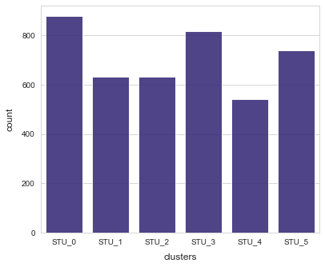

```python
cl.plot_clustercount() #output_path='PATH.jpg')
```

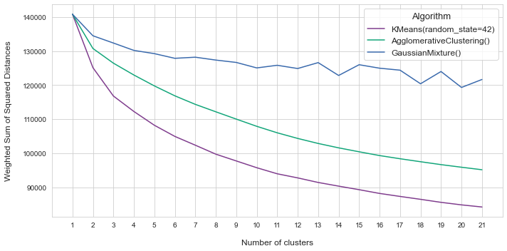

```python
cl.plot_score_comparison()
```

The code below plots the normalized WSS and difference curve used by the elbow method.

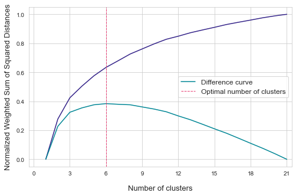

```python
cl.plot_optimal_components_normalized() #output_path='PATH.jpg')
```

## 3. Analysis of clusters

### 3.1. Descriptive statistics by cluster

#### 3.1.1. Internal variables

```python
# Internal variables
cl.describe_clusters(variables=['dim_01', 'dim_12'], statistics='mean')
```

|  | cluster | dim_01 mean | dim_12 mean |
| --- | --- | --- | --- |
| 0 | 0 | 0.0252 | -0.2593 |
| 1 | 1 | -1.9755 | 0.0030 |
| 2 | 2 | 1.0161 | -0.1696 |
| 3 | 3 | 1.3719 | -0.0601 |
| 4 | 4 | -0.4115 | 0.4950 |
| 5 | 5 | -0.4197 | 0.1530 |

```python
cl.describe_clusters()
```

|  | cluster | dim_01 mean | dim_01 median | dim_01 std | dim_02 mean | dim_02 median | dim_02 std | dim_03 mean | dim_03 median | dim_03 std | dim_04 mean | dim_04 median | dim_04 std | dim_05 mean | dim_05 median | dim_05 std | dim_06 mean | dim_06 median | dim_06 std | dim_07 mean | dim_07 median | dim_07 std | dim_08 mean | dim_08 median | dim_08 std | dim_09 mean | dim_09 median | dim_09 std | dim_10 mean | … |
| --- | --- | --- | --- | --- | --- | --- | --- | --- | --- | --- | --- | --- | --- | --- | --- | --- | --- | --- | --- | --- | --- | --- | --- | --- | --- | --- | --- | --- | --- | --- |
| 0 | 0 | 0.0252 | 0.0670 | 1.5275 | -0.8387 | -0.7252 | 1.4527 | 1.5956 | 1.7462 | 1.0832 | -0.0393 | -0.0099 | 1.3690 | 0.1465 | 0.1557 | 1.3121 | -0.3626 | -0.3482 | 1.3097 | 0.4990 | 0.5058 | 1.2849 | -0.5697 | -0.6460 | 1.1820 | -0.4214 | -0.4389 | 1.2866 | 0.3105 | … |
| 1 | 1 | -1.9755 | -1.9126 | 1.4909 | 0.1879 | 0.0842 | 1.5732 | 0.2328 | 0.2020 | 1.5489 | 1.1677 | 1.1685 | 1.6655 | -0.6273 | -0.6968 | 1.5062 | 0.5481 | 0.6054 | 1.3996 | -1.1098 | -1.0915 | 1.4268 | 0.4324 | 0.2690 | 1.5430 | 0.3077 | 0.3351 | 1.4750 | 0.4208 | … |
| 2 | 2 | 1.0161 | 1.0166 | 1.7075 | -1.7001 | -1.6210 | 1.5671 | 1.5056 | 1.7091 | 1.2311 | -0.7775 | -0.8744 | 1.5966 | 1.2308 | 1.3123 | 1.3235 | 1.1202 | 1.1628 | 1.4188 | -1.2466 | -1.1882 | 1.4883 | 1.1513 | 1.0418 | 1.6489 | 0.8434 | 0.7949 | 1.4794 | -0.4126 | … |
| 3 | 3 | 1.3719 | 1.3743 | 1.3642 | 0.7016 | 0.6506 | 1.4348 | -1.4567 | -1.4928 | 1.1886 | -0.5729 | -0.6552 | 1.5492 | 0.9376 | 0.9799 | 1.3497 | 0.7802 | 0.7368 | 1.3225 | -0.1449 | -0.1927 | 1.3866 | 0.1941 | 0.1105 | 1.4581 | 0.2961 | 0.2624 | 1.4056 | 0.0096 | … |
| 4 | 4 | -0.4115 | -0.3328 | 1.4871 | -0.1404 | -0.0630 | 1.5568 | -0.1659 | -0.2814 | 1.5596 | 0.1387 | 0.1817 | 1.3852 | -1.0157 | -1.0809 | 1.2998 | -1.3675 | -1.4594 | 1.3760 | 0.6987 | 0.7163 | 1.2113 | -0.5230 | -0.5245 | 1.4101 | 0.1495 | 0.1664 | 1.2578 | -1.6330 | … |
| 5 | 5 | -0.4197 | -0.3857 | 1.4972 | 1.6147 | 1.5069 | 1.5053 | -1.6484 | -1.6557 | 1.1544 | 0.2417 | 0.2109 | 1.4751 | -0.9779 | -0.9311 | 1.3207 | -0.8529 | -0.8292 | 1.3105 | 1.0690 | 1.0660 | 1.2119 | -0.5069 | -0.5450 | 1.3739 | -0.9202 | -0.9346 | 1.2716 | 0.8122 | … |

#### 3.1.2. External variables

```python
# External variables - We use (some of) the original variables
cl.describe_clusters(df_original[num_vars], variables=num_vars, statistics='mean')
```

|  | cluster | AGE mean | PAREDINT mean | BMMJ1 mean | BFMJ2 mean | HISEI mean | DURECEC mean | BSMJ mean | MMINS mean | LMINS mean | SMINS mean | TMINS mean | FCFMLRTY mean | SCCHANGE mean | CHANGE mean | STUBMI mean | ESCS mean | UNDREM mean | METASUM mean | METASPAM mean | ICTHOME mean | ICTSCH mean | HOMEPOS mean | CULTPOSS mean | HEDRES mean | WEALTH mean | ICTRES mean | DISCLIMA mean | TEACHSUP mean | … |
| --- | --- | --- | --- | --- | --- | --- | --- | --- | --- | --- | --- | --- | --- | --- | --- | --- | --- | --- | --- | --- | --- | --- | --- | --- | --- | --- | --- | --- | --- | --- |
| 0 | 0 | 15.8465 | 15.5207 | 59.4881 | 57.9274 | 69.5708 | 3.1401 | 73.2997 | 215.3645 | 206.1306 | 205.2904 | 1729.8292 | 7.1754 | 0.2426 | 0.3353 | 20.5023 | 0.7836 | 0.4421 | 0.5031 | 0.1596 | 9.3132 | 5.9385 | 0.4413 | 0.2399 | 0.1045 | 0.4137 | 0.3276 | 0.0819 | 0.1564 | … |
| 1 | 1 | 15.8448 | 14.4345 | 44.2078 | 42.3823 | 52.4898 | 3.0790 | 72.9757 | 217.2196 | 208.0319 | 180.4818 | 1692.3934 | 8.1801 | 0.3697 | 0.4850 | 21.3376 | 0.1224 | 0.4183 | 0.5521 | 0.3751 | 8.7994 | 5.3902 | 0.0483 | 0.1825 | -0.2113 | -0.0440 | -0.0693 | -0.6004 | -0.7558 | … |
| 2 | 2 | 15.8616 | 15.5107 | 58.9674 | 57.5143 | 68.2804 | 3.0681 | 73.8632 | 224.7385 | 214.7861 | 231.8463 | 1765.3011 | 10.2536 | 0.2837 | 0.3821 | 20.9419 | 0.9598 | 0.4609 | 0.5057 | 0.2829 | 9.7417 | 6.5468 | 0.9153 | 0.7005 | 0.4595 | 0.6766 | 0.7025 | 0.0654 | 0.4818 | … |
| 3 | 3 | 15.8287 | 12.1485 | 26.9159 | 27.8155 | 33.1415 | 2.9804 | 68.7257 | 228.2313 | 228.2521 | 184.0514 | 1707.9437 | 8.3525 | 0.3244 | 0.4706 | 21.3676 | -0.7540 | 0.3303 | 0.3704 | 0.0119 | 8.5716 | 6.2705 | -0.2836 | -0.1848 | -0.0913 | -0.2451 | -0.3706 | -0.0179 | 0.6966 | … |
| 4 | 4 | 15.8297 | 14.2265 | 40.3160 | 37.6802 | 47.4717 | 3.0368 | 62.0249 | 225.3223 | 219.4383 | 199.1529 | 1767.1087 | 6.4438 | 0.5506 | 0.8659 | 21.1769 | -0.0176 | -0.2443 | -0.2992 | -0.4205 | 9.4199 | 7.4254 | 0.0252 | -0.0996 | -0.0591 | 0.1292 | -0.0110 | -0.4202 | -0.1462 | … |
| 5 | 5 | 15.8233 | 11.5054 | 25.2390 | 27.7232 | 31.7569 | 2.8498 | 61.7184 | 222.1313 | 214.1570 | 185.4060 | 1692.4154 | 5.1502 | 0.4127 | 0.5900 | 21.6838 | -1.0691 | 0.1567 | 0.2485 | -0.1435 | 7.7970 | 5.6143 | -0.7304 | -0.6552 | -0.6519 | -0.4746 | -0.6314 | -0.2025 | 0.0083 | … |

```python
# Use the original variables - Some of them
cl.describe_clusters_cat(df_original['REPEAT'], cat_name='REPEAT', normalize=True)
```

| REPEAT Clusters | 0.0 | 1.0 |
| --- | --- | --- |
| STU_0 | 0.9260 | 0.0740 |
| STU_1 | 0.8736 | 0.1264 |
| STU_2 | 0.9414 | 0.0586 |
| STU_3 | 0.7209 | 0.2791 |
| STU_4 | 0.6409 | 0.3591 |
| STU_5 | 0.5616 | 0.4384 |

```python
cl.describe_clusters_cat(df_original['ST004D01T'], cat_name='ST004D01T', normalize=True)
```

| ST004D01T Clusters | 1.0 | 2.0 |
| --- | --- | --- |
| STU_0 | 0.5626 | 0.4374 |
| STU_1 | 0.6303 | 0.3697 |
| STU_2 | 0.5436 | 0.4564 |
| STU_3 | 0.5936 | 0.4064 |
| STU_4 | 0.2891 | 0.7109 |
| STU_5 | 0.4750 | 0.5250 |

### 3.2. Cluster means vs global means comparison

#### 3.2.1. Internal variables

```python
cl.compare_cluster_means_to_global_means()
```

|  | cluster | dim_01 | dim_02 | dim_03 | dim_04 | dim_05 | dim_06 | dim_07 | dim_08 | dim_09 | dim_10 | dim_11 | dim_12 | dim_13 | dim_14 |
| --- | --- | --- | --- | --- | --- | --- | --- | --- | --- | --- | --- | --- | --- | --- | --- |
| 0 | 0 | 0.0252 | -0.8387 | 1.5956 | -0.0393 | 0.1465 | -0.3626 | 0.4990 | -0.5697 | -0.4214 | 0.3105 | 0.7804 | -0.2593 | -0.1935 | -0.2364 |
| 1 | 1 | -1.9755 | 0.1879 | 0.2328 | 1.1677 | -0.6273 | 0.5481 | -1.1098 | 0.4324 | 0.3077 | 0.4208 | -0.0356 | 0.0030 | -0.1868 | -0.1378 |
| 2 | 2 | 1.0161 | -1.7001 | 1.5056 | -0.7775 | 1.2308 | 1.1202 | -1.2466 | 1.1513 | 0.8434 | -0.4126 | -0.1119 | -0.1696 | 0.0861 | -0.2326 |
| 3 | 3 | 1.3719 | 0.7016 | -1.4567 | -0.5729 | 0.9376 | 0.7802 | -0.1449 | 0.1941 | 0.2961 | 0.0096 | 0.0399 | -0.0601 | 0.1937 | 0.1442 |
| 4 | 4 | -0.4115 | -0.1404 | -0.1659 | 0.1387 | -1.0157 | -1.3675 | 0.6987 | -0.5230 | 0.1495 | -1.6330 | -1.5430 | 0.4950 | 0.1293 | 0.1575 |
| 5 | 5 | -0.4197 | 1.6147 | -1.6484 | 0.2417 | -0.9779 | -0.8529 | 1.0690 | -0.5069 | -0.9202 | 0.8122 | 0.2884 | 0.1530 | 0.0073 | 0.3224 |

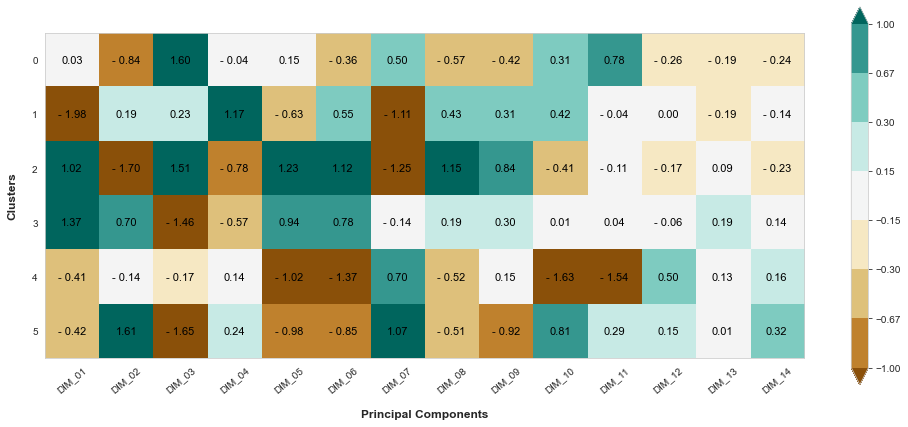

```python
cl.plot_cluster_means_to_global_means_comparison(xlabel='Principal Components', ylabel='Clusters',
                                                 levels=[-1, -0.67, -0.3, -0.15, 0.15, 0.3, 0.67, 1])
```

#### 3.2.2. External variables

Note that for external variables we normalize variables to the 0-1 scale in order to make fair comparisons.

```python
mms = MinMaxScaler()
```

```python
cl.compare_cluster_means_to_global_means(pd.DataFrame(mms.fit_transform(df_original[num_vars_sel]), columns=num_vars_sel))
```

|  | cluster | HISEI | MMINS | LMINS | FCFMLRTY | SCCHANGE | CHANGE | ESCS | METASUM | ICTHOME | HOMEPOS | ICTRES | TEACHSUP | EMOSUPS | STIMREAD | ADAPTIVITY | JOYREAD | SCREADCOMP | SCREADDIFF | WORKMAST | GFOFAIL | RESILIENCE | MASTGOAL | PERSPECT | RESPECT | GLOBMIND | DISCRIM | COMPICT | INFOCAR | … |
| --- | --- | --- | --- | --- | --- | --- | --- | --- | --- | --- | --- | --- | --- | --- | --- | --- | --- | --- | --- | --- | --- | --- | --- | --- | --- | --- | --- | --- | --- | --- |
| 0 | 0 | 0.3346 | -0.0298 | -0.0415 | -0.0513 | -0.3118 | -0.3334 | 0.2430 | 0.0802 | 0.0456 | 0.1208 | 0.0930 | 0.0171 | 0.0986 | -0.0377 | -0.0048 | -0.0692 | -0.1083 | 0.1075 | -0.0274 | -0.0240 | -0.0559 | -0.0258 | -0.0399 | 0.0056 | -0.0400 | -0.2855 | -0.0795 | -0.0617 | … |
| 1 | 1 | 0.0366 | -0.0214 | -0.0327 | 0.0815 | 0.0487 | -0.0357 | 0.0407 | 0.1039 | -0.0121 | -0.0024 | -0.0129 | -0.3065 | -0.1649 | -0.3485 | -0.3347 | 0.2030 | 0.2046 | -0.2021 | -0.0340 | 0.1957 | -0.0893 | -0.0760 | 0.0302 | 0.0521 | 0.0437 | 0.1602 | 0.0497 | 0.0369 | … |
| 2 | 2 | 0.3121 | 0.0125 | -0.0013 | 0.3557 | -0.1953 | -0.2404 | 0.2969 | 0.0814 | 0.0937 | 0.2694 | 0.1930 | 0.1326 | 0.1743 | 0.2442 | 0.2062 | 0.1691 | 0.2518 | -0.2620 | 0.1945 | -0.0202 | 0.2723 | 0.2971 | 0.1311 | 0.0823 | 0.1797 | -0.1813 | 0.2084 | 0.2071 | … |
| 3 | 3 | -0.3010 | 0.0282 | 0.0613 | 0.1043 | -0.0799 | -0.0644 | -0.2275 | 0.0157 | -0.0376 | -0.1065 | -0.0934 | 0.2088 | 0.1309 | 0.2818 | 0.2398 | 0.0476 | 0.0638 | -0.0449 | 0.1386 | -0.0350 | 0.1425 | 0.1626 | 0.1004 | 0.0742 | 0.0660 | -0.2229 | 0.0374 | 0.0122 | … |
| 4 | 4 | -0.0510 | 0.0151 | 0.0203 | -0.1480 | 0.5621 | 0.7215 | -0.0022 | -0.3096 | 0.0576 | -0.0097 | 0.0026 | -0.0902 | -0.1822 | -0.0415 | -0.0742 | -0.1745 | -0.1625 | 0.1431 | -0.1576 | -0.0350 | -0.1054 | -0.1339 | -0.1475 | -0.2098 | -0.1081 | 0.7617 | -0.0908 | 0.1415 | … |
| 5 | 5 | -0.3251 | 0.0007 | -0.0042 | -0.3191 | 0.1708 | 0.1730 | -0.3239 | -0.0436 | -0.1246 | -0.2466 | -0.1629 | -0.0354 | -0.1355 | -0.1464 | -0.0943 | -0.1604 | -0.2127 | 0.2137 | -0.1418 | -0.0574 | -0.1697 | -0.2393 | -0.0930 | -0.0494 | -0.1368 | 0.0435 | -0.1007 | -0.2526 | … |

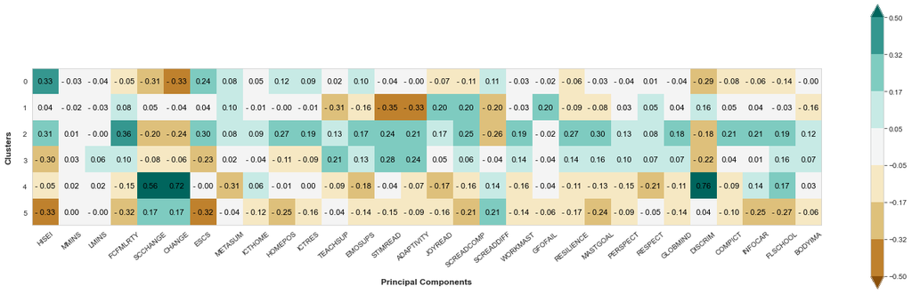

```python
cl.plot_cluster_means_to_global_means_comparison(df_original=pd.DataFrame(mms.fit_transform(df_original[num_vars_sel]), columns=num_vars_sel),
                                                 xlabel='Principal Components', ylabel='Clusters', use_weights=True)
```

### 3.3. Significance tests

```python
# ANOVA tests for internal variables
cl.anova_tests(cluster_filter=[4, 5], vars_test=['dim_01', 'dim_05', 'dim_12'])
```

|  | var_name | df | sum_sq | mean_sq | F | PR(>F) |
| --- | --- | --- | --- | --- | --- | --- |
| 0 | dim_01 | 1.0000 | 0.0213 | 0.0213 | 0.0096 | 0.9221 |
| 1 | dim_05 | 1.0000 | 0.4465 | 0.4465 | 0.2594 | 0.6106 |
| 2 | dim_12 | 1.0000 | 36.6106 | 36.6106 | 15.6459 | 0.0001 |

```python
cl.anova_tests(cluster_filter=[4, 5], vars_test=['dim_02', 'dim_03'])
```

|  | var_name | df | sum_sq | mean_sq | F | PR(>F) |
| --- | --- | --- | --- | --- | --- | --- |
| 0 | dim_02 | 1.0000 | 964.1642 | 964.1642 | 413.3332 | 0.0000 |
| 1 | dim_03 | 1.0000 | 687.8566 | 687.8566 | 382.5211 | 0.0000 |

```python
# ANOVA tests for External variables
cl.anova_tests(cluster_filter=[4, 5], df_test=df_original[['HOMEPOS', 'ESCS']])
```

|  | var_name | df | sum_sq | mean_sq | F | PR(>F) |
| --- | --- | --- | --- | --- | --- | --- |
| 0 | HOMEPOS | 1.0000 | 178.7145 | 178.7145 | 423.8790 | 0.0000 |
| 1 | ESCS | 1.0000 | 346.1261 | 346.1261 | 631.4576 | 0.0000 |

```python
cl.chi2_test(df_original['ST004D01T'])
```

```
{'chi2': 178.02891150452703, 'p': 1.4104746127102006e-36, 'dof': 5}
```

```python
cl.chi2_test(df_original['REPEAT'])
```

```
{'chi2': 522.0124350576717, 'p': 1.4134275450439873e-110, 'dof': 5}
```

```python
cl.chi2_test(df_original['IMMIG'])
```

```
{'chi2': 162.13087966432343, 'p': 1.1763860907044687e-29, 'dof': 10}
```

### 3.4. Distribution comparisons (visualizations) for numerical variables

#### 3.4.1. Internal variables

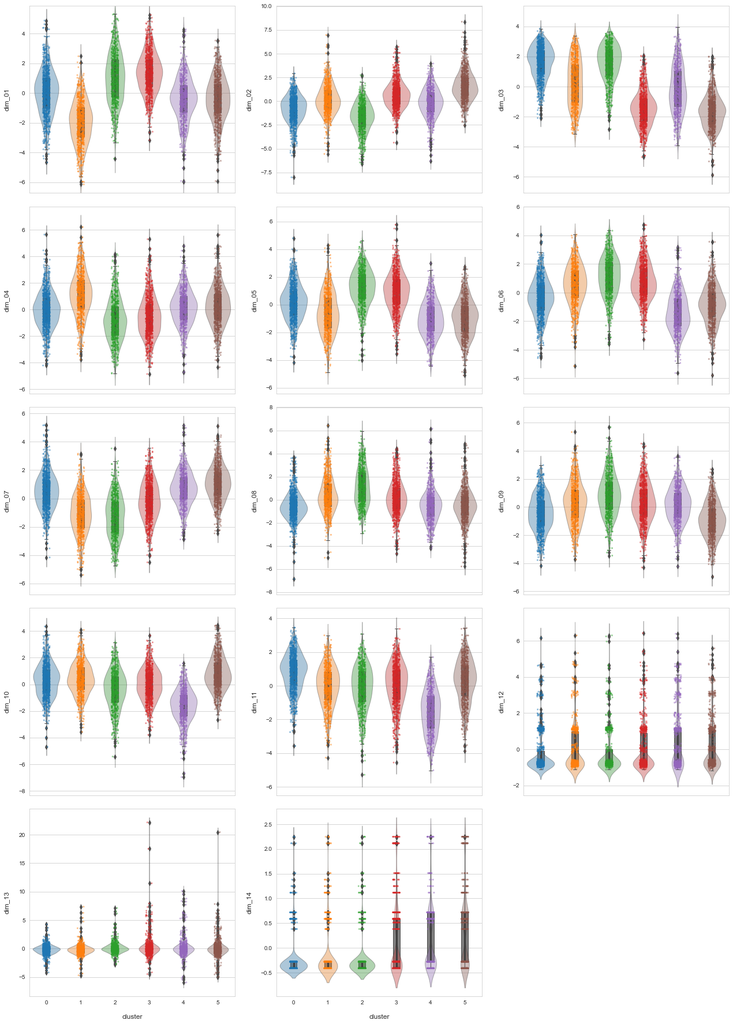

```python
# Internal variables
cl.plot_distribution_comparison_by_cluster()
```

#### 3.4.2. External variables

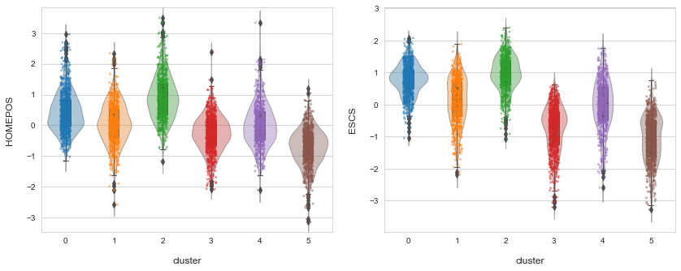

```python
# External variables
cl.plot_distribution_comparison_by_cluster(df_ext=df_original[['HOMEPOS', 'ESCS']])
```

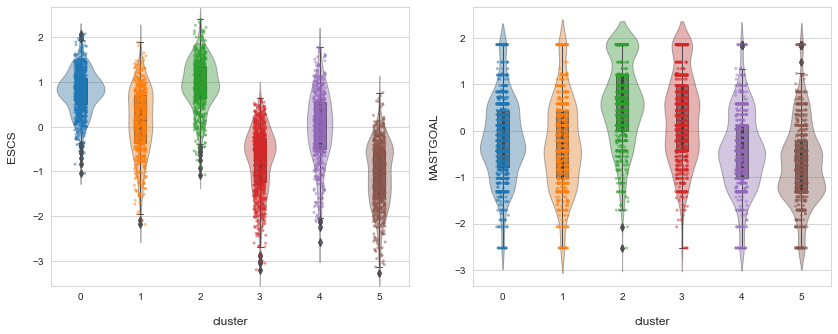

```python
# External variables
cl.plot_distribution_comparison_by_cluster(df_ext=df_original[['ESCS', 'MASTGOAL']])
```

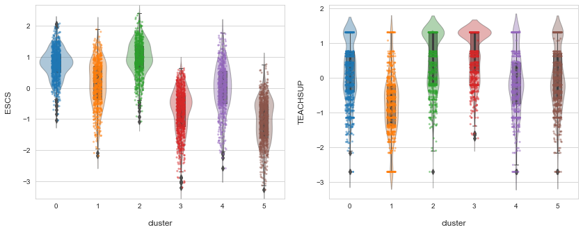

```python
cl.plot_distribution_comparison_by_cluster(df_ext=df_original[['ESCS', 'TEACHSUP']]) #, output_path='PATH.jpg')
```

### 3.5. 2-Dimensional plots for numerical variables

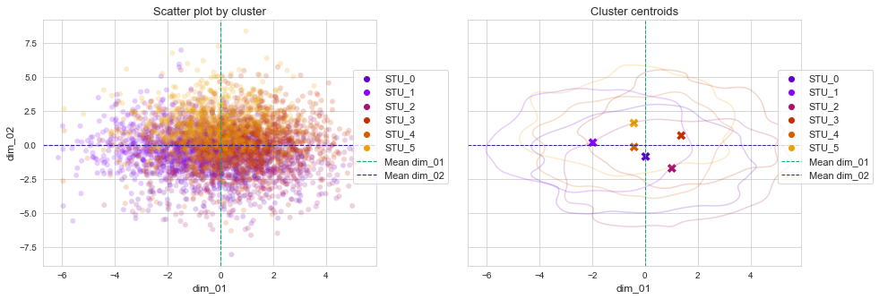

```python
# Internal variables
cl.plot_clusters_2D('dim_01', 'dim_02', style_kwargs=dict(kdeplot=True, alpha=0.2)) #, output_path='PATH.jpg')
```

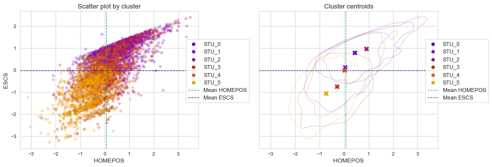

```python
#External Variables
cl.plot_clusters_2D(df_original['HOMEPOS'], df_original['ESCS'])
```

### 3.6. Distribution comparisons (visualization) for categorical variables

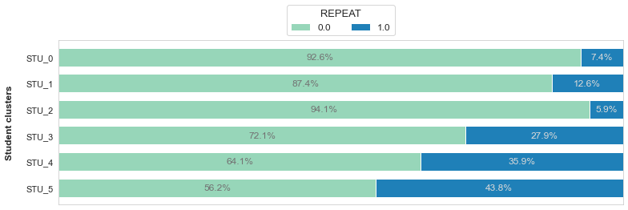

```python
cl.plot_cat_distribution_by_cluster(df_original['REPEAT'], cat_label='REPEAT', cluster_label='Student clusters')
```

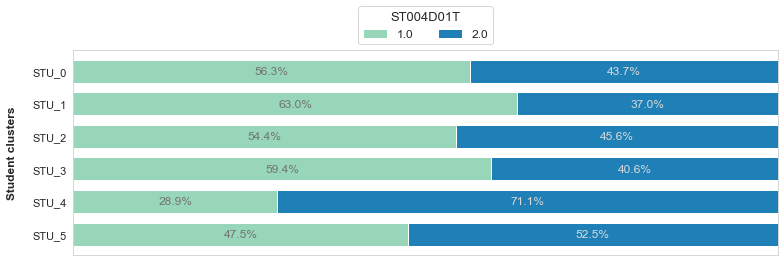

```python
cl.plot_cat_distribution_by_cluster(df_original['ST004D01T'], cat_label='ST004D01T', cluster_label='Student clusters')
```

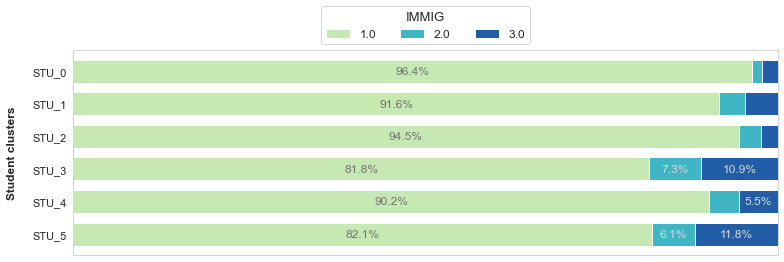

```python
cl.plot_cat_distribution_by_cluster(df_original['IMMIG'], cat_label='IMMIG', cluster_label='Student clusters')
```

## Export results

Export results:

- One data set with the clusters associated to the extracted components;
- Another one with the clusters associated to the original data.

```python
# cl.df.to_csv('../../data/pisa_spain_sample_v2_preprocessed_dim_red_clustered_output.csv', index=False)
```

```python
# df_original['cluster'] = cl.df['cluster'].values
# df_original['cluster_cat'] = cl.df['cluster_cat'].values
# df_original.to_csv('../../data/pisa_spain_sample_v2_preprocessed_clustered_output.csv', index=False)
```

## Reproducibility

```python
df_ref = pd.read_csv('data/pisa_spain_sample_v2_preprocessed_dim_red_clustered_output.csv')

print('Diff', (df_ref['cluster'] != cl.df['cluster']).sum())
```

```
Diff 0
```